# Relation between Moments across Datasets

TSS from abs values; Dataset 1: thsh 10

Lucia Campese

Jul 2021

### Aim

We want to find the theoretical distributions that better fit our data; to do that, we study the relation between the moments of our distributions (mean and variance, skewness and kurtosis).

### Datasets

#### metaB:

V9 region; OTU relative abundances; Diatoms; 20-180, SUR. File: barv2016202_swarm_d1_t100.

#### metaG:

MATOU-v2 unigene relative abundances (RPKM normalization) renormalized on diatoms total abundance per station; Diatoms; 20-180; SUR

#### metaT:

MATOU-v2 unigene relative abundances (RPKM normalization) renormalized on diatoms total abundance per station; Diatoms; 20-180; SUR

### Note:

the three dataset have been filtered in the following way:

1. Abundance filter: keep, in each station, only OTUs/unigenes with readcounts > 10 [this reduces the local effect of tails of rare OTUs/unigenes while keeping them at global scale]
2. Also, for metaT: keep only unigenes that are present in metaG [biological criterion]

(v.script file:///C:/Users/Userszn/Documents/PhD/Thesis_writing/1st_Chapter/scripts/make_thsh_all.R)

| Feature | metaB | metaG | metaT |
| --- | --- | --- | --- |
| unit | OTU | unigene | trascribed unigene |
| condition | sampling station | sampling station | sampling station |
| value type | rel.ab (sum per st=1) | rel.ab (RPKM+dia) | rel.ab(RPKM+dia) |

## A) Community level: Relation between variables (columns)

How can we address whether the variability we observe between sampling stations is due to a real biological signal or to background noise/technical biases?

### 1. Richness

#### metaB

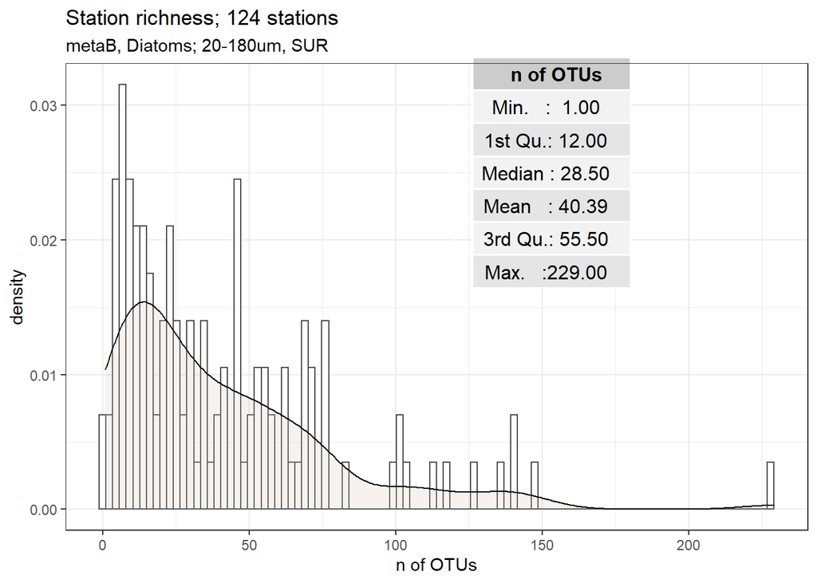

#### metaG

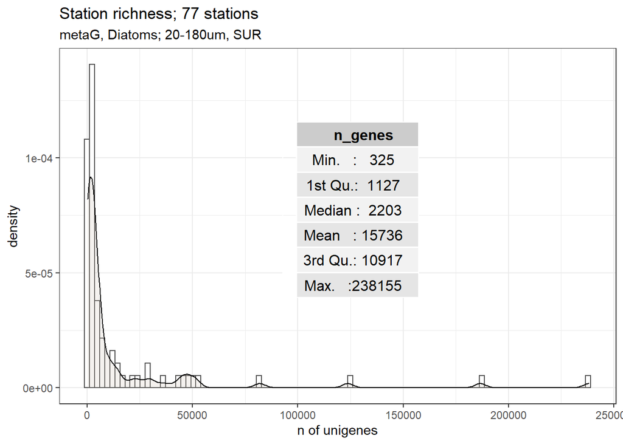

#### metaT

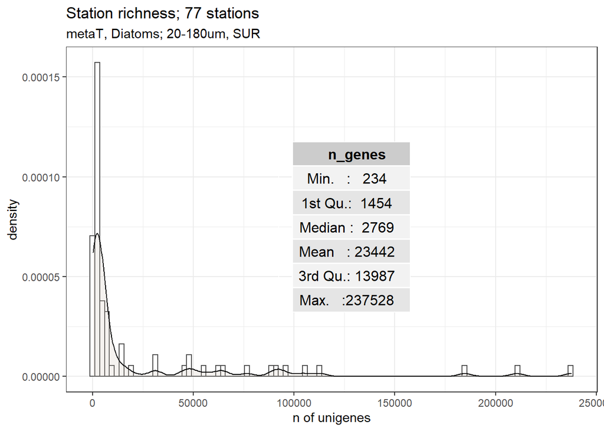

### 2. RAD

#### metaB

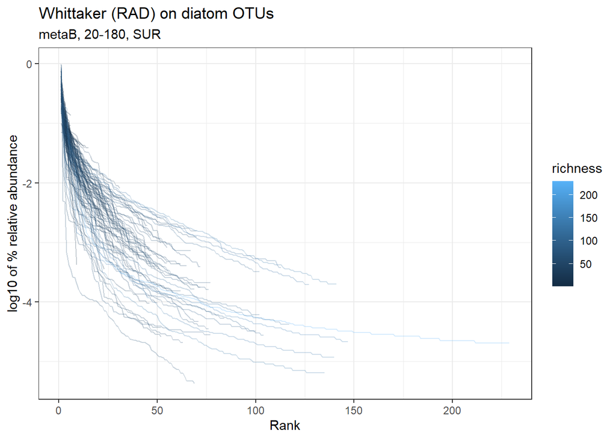

#### metaG

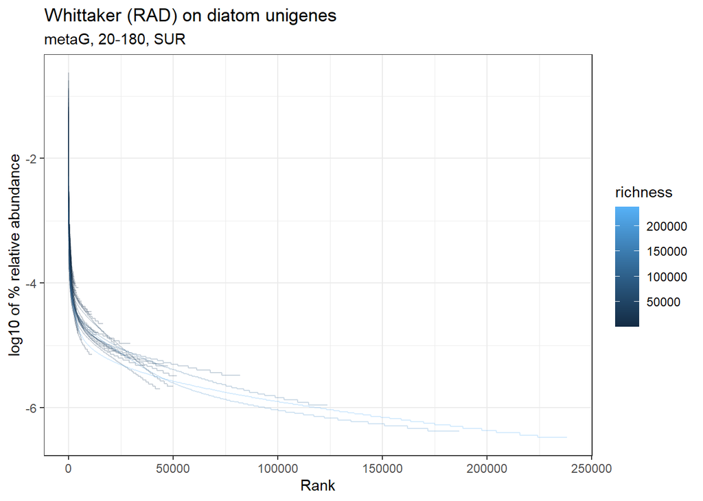

#### metaT

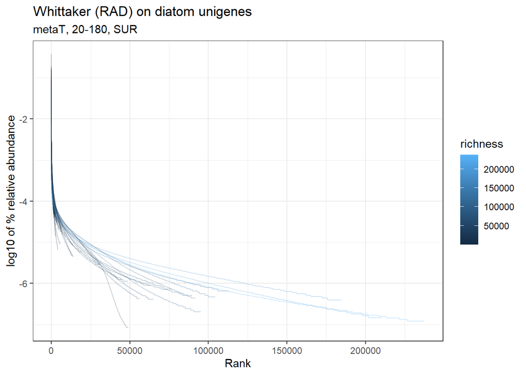

### 3. Relation between moments : mean-variance

#### metaB

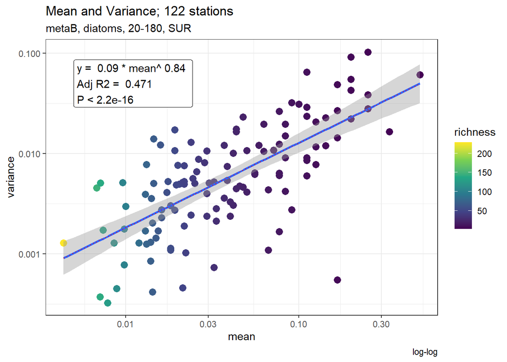

#### metaG

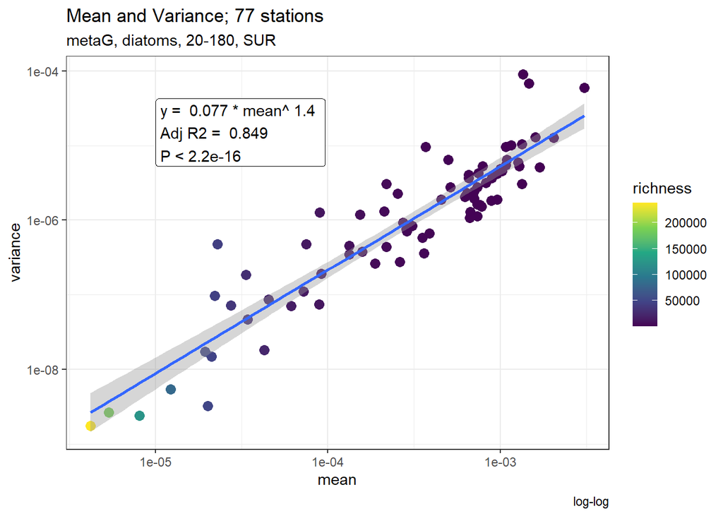

#### metaT

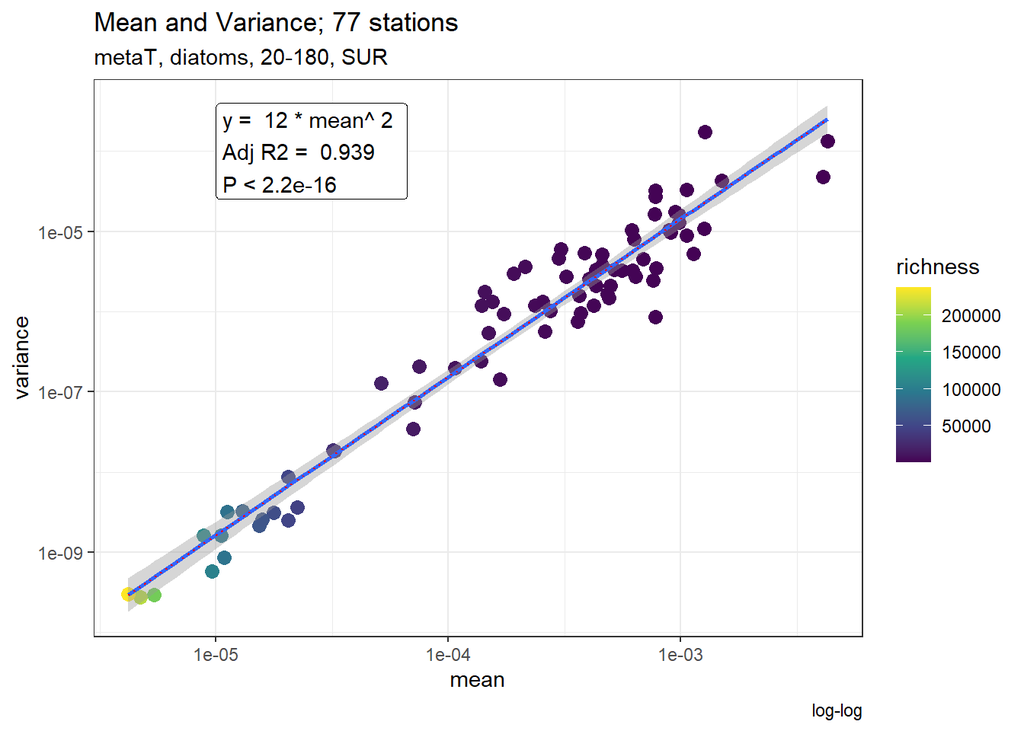

#### all (TARA)

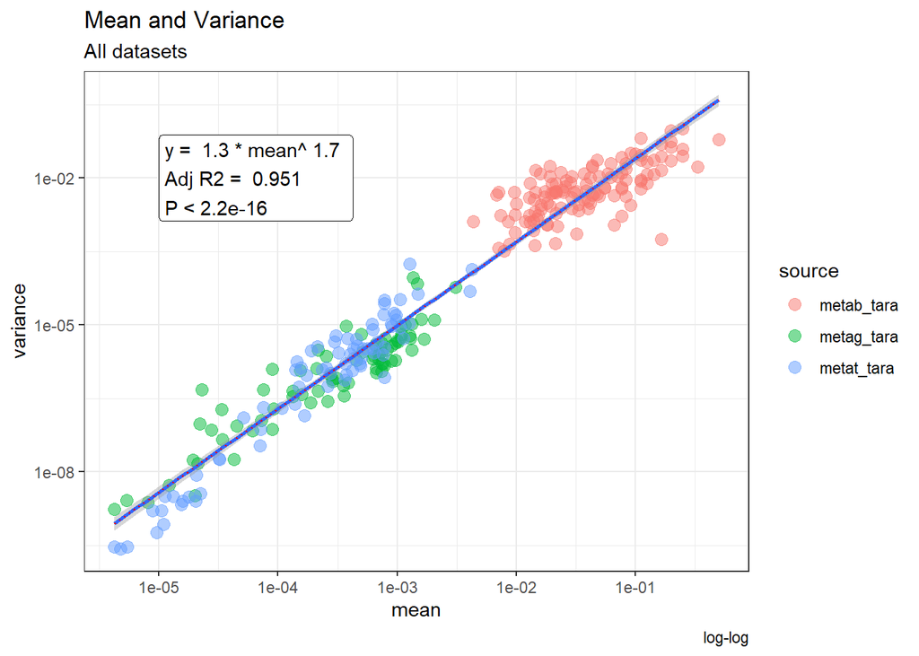

### 4. Q-Q plots

#### Original

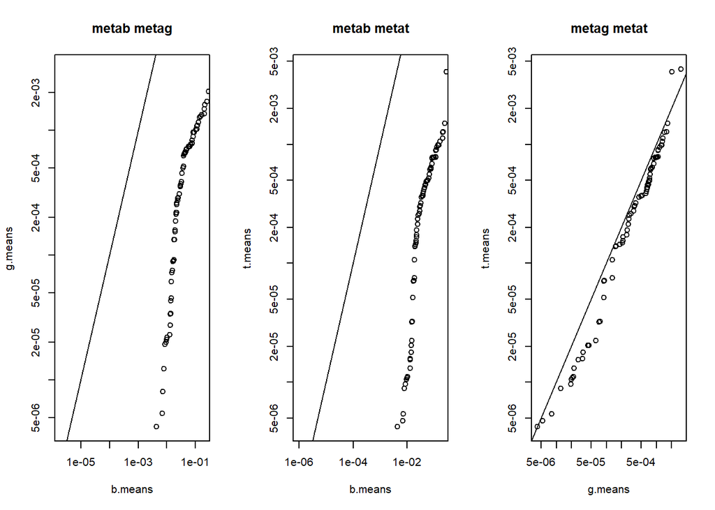

#### Transformed

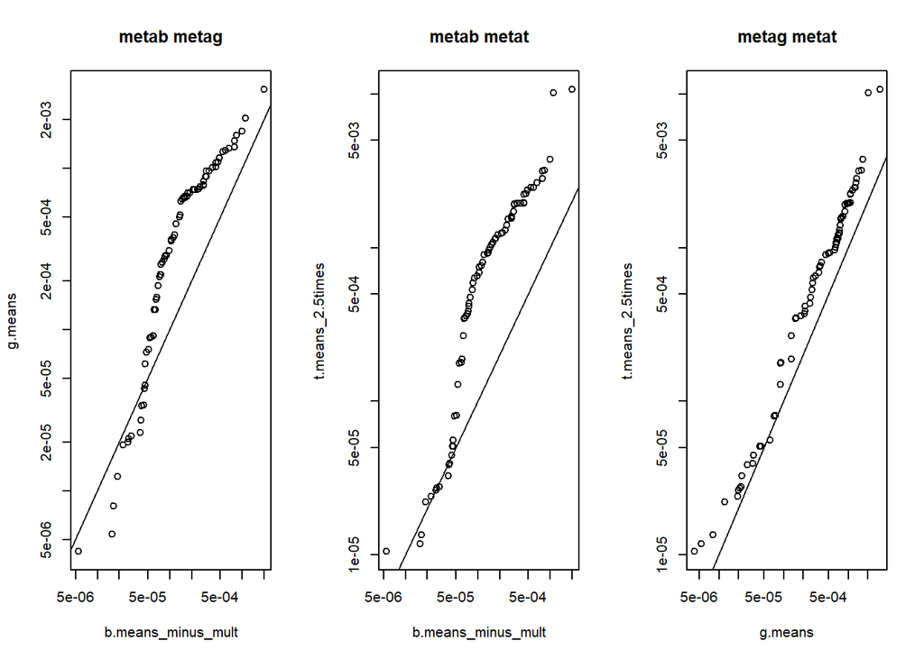

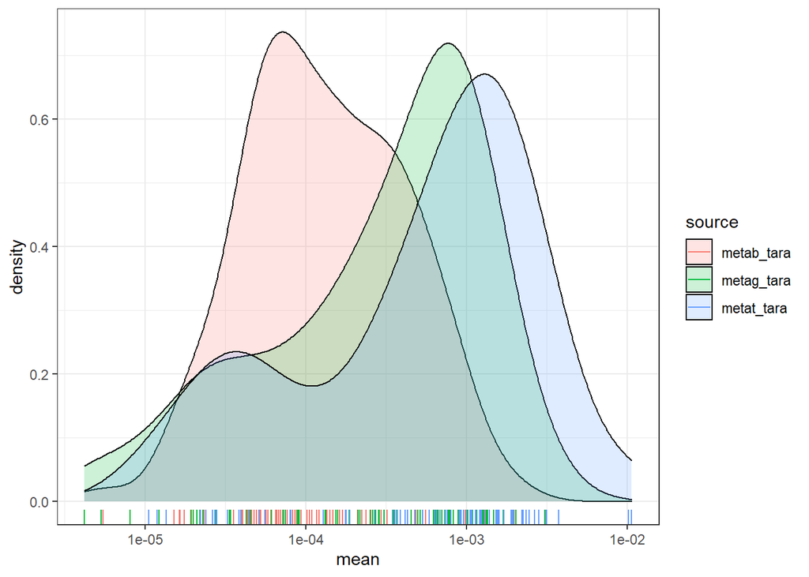

### 5. Relation between moments : skewness-kurtosis

#### metaB

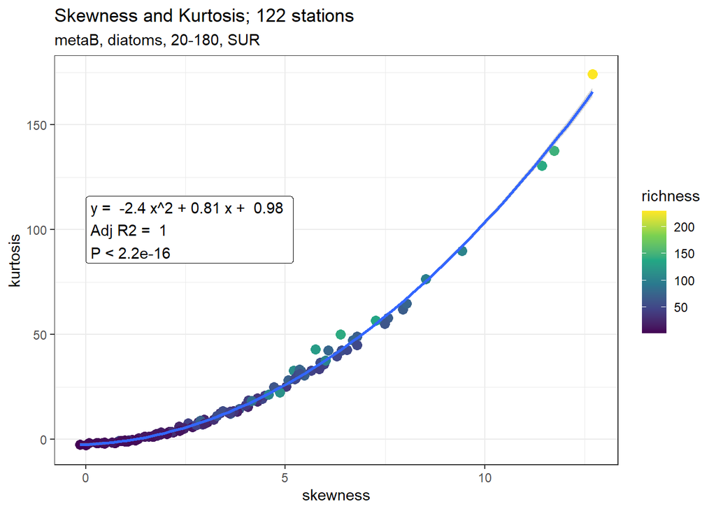

#### metaG

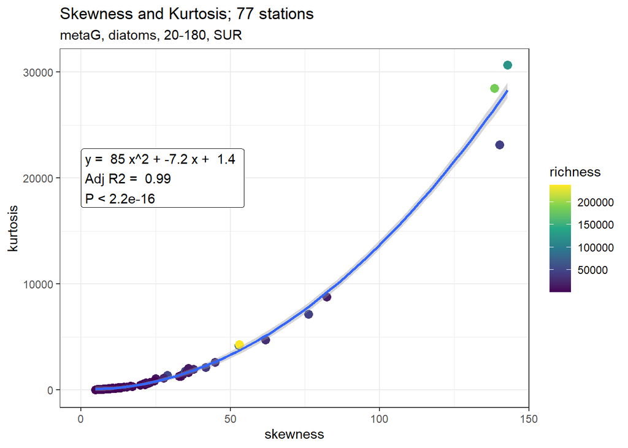

#### metaT

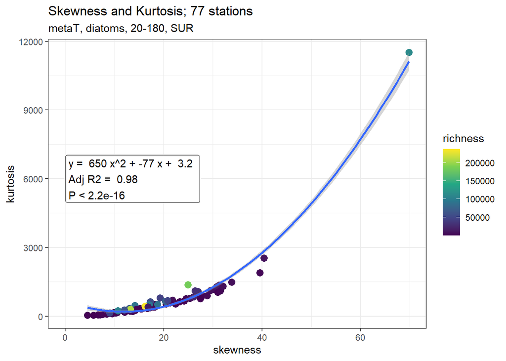

#### all (TARA)

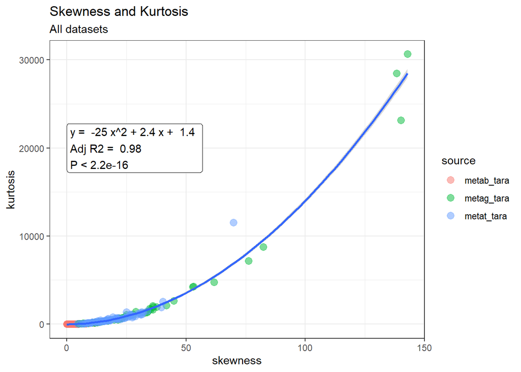

### Among Datasets

#### metaB - metaG

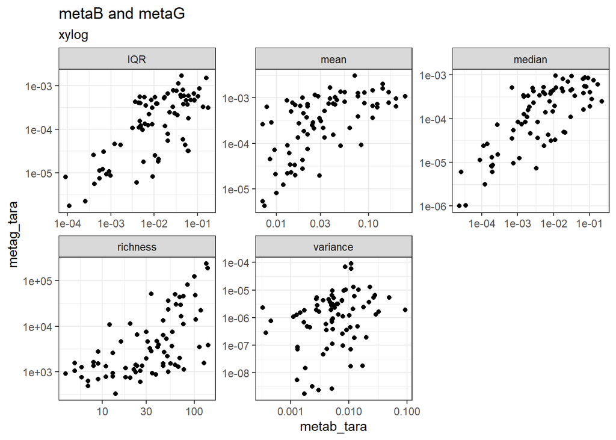

#### metaB - metaT

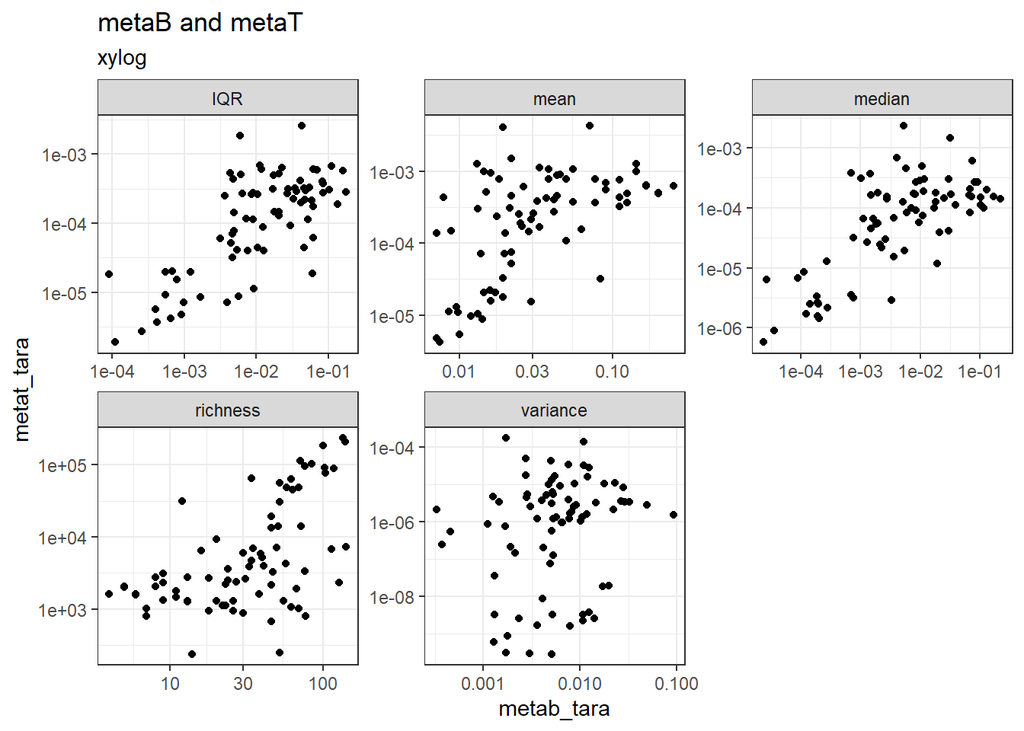

#### metaG - metaT

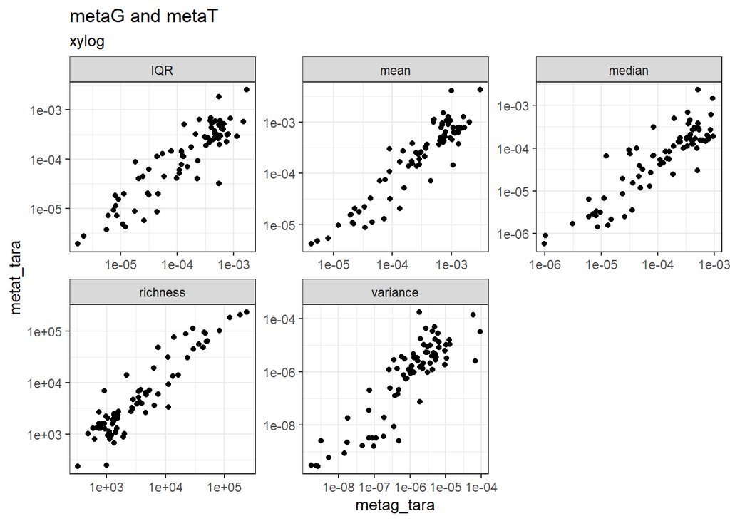